# Development of a Movie Recomender

Ademola Apata

7/7/2020

## Project Overview

This project focuses on the development of a collborative filtering system (CFR) for recommending movies.

In this project, in order to recommend movies, a large set of users preferences towards different movies is obtained from a publicly available movie rating dataset.

## Installing packages

```r
#install.packages("rlang", type = "source",dependencies = TRUE)
library(data.table)
#install.packages("recommenderlab")
#install.packages("plyr")
#install.packages("dplyr")
library(dplyr)
library(recommenderlab)
#install.packages("ggplot2",repos = c("http://rstudio.org/_packages","http://cran.rstudio.com"))
library(ggplot2)
#install.packages("reshape2",repos = c("http://rstudio.org/_packages","http://cran.rstudio.com"))
library(reshape2)
```

## Movie Summary and first several rows in a Dataframe

```
##     movieId          title              genres
##  Min.   :     1   Length:10329       Length:10329
##  1st Qu.:  3240   Class :character   Class :character
##  Median :  7088   Mode  :character   Mode  :character
##  Mean   : 31924
##  3rd Qu.: 59900
##  Max.   :149532
```

|  | movieId | title | genres |
| --- | --- | --- | --- |
| 1 | 1 | Toy Story (1995) | Adventure\|Animation\|Children\|Comedy\|Fantasy |
| 2 | 2 | Jumanji (1995) | Adventure\|Children\|Fantasy |
| 3 | 3 | Grumpier Old Men (1995) | Comedy\|Romance |
| 4 | 4 | Waiting to Exhale (1995) | Comedy\|Drama\|Romance |
| 5 | 5 | Father of the Bride Part II (1995) | Comedy |
| 6 | 6 | Heat (1995) | Action\|Crime\|Thriller |

```
##      userId         movieId           rating        timestamp
##  Min.   :  1.0   Min.   :     1   Min.   :0.500   Min.   :8.286e+08
##  1st Qu.:192.0   1st Qu.:  1073   1st Qu.:3.000   1st Qu.:9.711e+08
##  Median :383.0   Median :  2497   Median :3.500   Median :1.115e+09
##  Mean   :364.9   Mean   : 13381   Mean   :3.517   Mean   :1.130e+09
##  3rd Qu.:557.0   3rd Qu.:  5991   3rd Qu.:4.000   3rd Qu.:1.275e+09
##  Max.   :668.0   Max.   :149532   Max.   :5.000   Max.   :1.452e+09
```

|  | userId | movieId | rating | timestamp |
| --- | --- | --- | --- | --- |
| 1 | 1 | 16 | 4.0 | 1217897793 |
| 2 | 1 | 24 | 1.5 | 1217895807 |
| 3 | 1 | 32 | 4.0 | 1217896246 |
| 4 | 1 | 47 | 4.0 | 1217896556 |
| 5 | 1 | 50 | 4.0 | 1217896523 |
| 6 | 1 | 110 | 4.0 | 1217896150 |

## Data Pre-processing

we need to convert the genres present in the movie_data dataframe into a more usable format by the users. A matrix that comprises of corresponding genres for each of the films was created. Information of movie genres are reorganized from a design perspective to make it much easier for users to be compared with each other from a very long list of movies available in the dataset.

### Extracting a list of genres

|  | Action | Adventure | Animation | Children | Comedy | Crime | Documentary | Drama | Fantasy | Film-Noir | Horror | Musical | Mystery | Romance | Sci-Fi | Thriller | War | Western |
| --- | --- | --- | --- | --- | --- | --- | --- | --- | --- | --- | --- | --- | --- | --- | --- | --- | --- | --- |
| 1 | 0 | 1 | 1 | 1 | 1 | 0 | 0 | 0 | 1 | 0 | 0 | 0 | 0 | 0 | 0 | 0 | 0 | 0 |
| 2 | 0 | 1 | 0 | 1 | 0 | 0 | 0 | 0 | 1 | 0 | 0 | 0 | 0 | 0 | 0 | 0 | 0 | 0 |
| 3 | 0 | 0 | 0 | 0 | 1 | 0 | 0 | 0 | 0 | 0 | 0 | 0 | 0 | 1 | 0 | 0 | 0 | 0 |
| 4 | 0 | 0 | 0 | 0 | 1 | 0 | 0 | 1 | 0 | 0 | 0 | 0 | 0 | 1 | 0 | 0 | 0 | 0 |
| 5 | 0 | 0 | 0 | 0 | 1 | 0 | 0 | 0 | 0 | 0 | 0 | 0 | 0 | 0 | 0 | 0 | 0 | 0 |
| 6 | 1 | 0 | 0 | 0 | 0 | 1 | 0 | 0 | 0 | 0 | 0 | 0 | 0 | 0 | 0 | 1 | 0 | 0 |

### Create a search matrix for a movie by genre

This will allow us to perform an easy search of the films by specifying the genre present in our movie list.

|  | movieId | title | Action | Adventure | Animation | Children | Comedy | Crime | Documentary | Drama | Fantasy | Film-Noir | Horror | Musical | Mystery | Romance | Sci-Fi | Thriller | War | Western |
| --- | --- | --- | --- | --- | --- | --- | --- | --- | --- | --- | --- | --- | --- | --- | --- | --- | --- | --- | --- | --- |
| 1 | 1 | Toy Story (1995) | 0 | 1 | 1 | 1 | 1 | 0 | 0 | 0 | 1 | 0 | 0 | 0 | 0 | 0 | 0 | 0 | 0 | 0 |
| 2 | 2 | Jumanji (1995) | 0 | 1 | 0 | 1 | 0 | 0 | 0 | 0 | 1 | 0 | 0 | 0 | 0 | 0 | 0 | 0 | 0 | 0 |
| 3 | 3 | Grumpier Old Men (1995) | 0 | 0 | 0 | 0 | 1 | 0 | 0 | 0 | 0 | 0 | 0 | 0 | 0 | 1 | 0 | 0 | 0 | 0 |
| 4 | 4 | Waiting to Exhale (1995) | 0 | 0 | 0 | 0 | 1 | 0 | 0 | 1 | 0 | 0 | 0 | 0 | 0 | 1 | 0 | 0 | 0 | 0 |
| 5 | 5 | Father of the Bride Part II (1995) | 0 | 0 | 0 | 0 | 1 | 0 | 0 | 0 | 0 | 0 | 0 | 0 | 0 | 0 | 0 | 0 | 0 | 0 |
| 6 | 6 | Heat (1995) | 1 | 0 | 0 | 0 | 0 | 1 | 0 | 0 | 0 | 0 | 0 | 0 | 0 | 0 | 0 | 1 | 0 | 0 |

```
## 'data.frame':    10329 obs. of  20 variables:
##  $ movieId    : int  1 2 3 4 5 6 7 8 9 10 ...
##  $ title      : chr  "Toy Story (1995)" "Jumanji (1995)" "Grumpier Old Men (1995)" "Waiting to Exhale (1995)" ...
##  $ Action     : int  0 0 0 0 0 1 0 0 1 1 ...
##  $ Adventure  : int  1 1 0 0 0 0 0 1 0 1 ...
##  $ Animation  : int  1 0 0 0 0 0 0 0 0 0 ...
##  $ Children   : int  1 1 0 0 0 0 0 1 0 0 ...
##  $ Comedy     : int  1 0 1 1 1 0 1 0 0 0 ...
##  $ Crime      : int  0 0 0 0 0 1 0 0 0 0 ...
##  $ Documentary: int  0 0 0 0 0 0 0 0 0 0 ...
##  $ Drama      : int  0 0 0 1 0 0 0 0 0 0 ...
##  $ Fantasy    : int  1 1 0 0 0 0 0 0 0 0 ...
##  $ Film-Noir  : int  0 0 0 0 0 0 0 0 0 0 ...
##  $ Horror     : int  0 0 0 0 0 0 0 0 0 0 ...
##  $ Musical    : int  0 0 0 0 0 0 0 0 0 0 ...
##  $ Mystery    : int  0 0 0 0 0 0 0 0 0 0 ...
##  $ Romance    : int  0 0 1 1 0 0 1 0 0 0 ...
##  $ Sci-Fi     : int  0 0 0 0 0 0 0 0 0 0 ...
##  $ Thriller   : int  0 0 0 0 0 1 0 0 0 1 ...
##  $ War        : int  0 0 0 0 0 0 0 0 0 0 ...
##  $ Western    : int  0 0 0 0 0 0 0 0 0 0 ...
```

### Converting ratings matrix in a proper format

Needed in order to use ratings data for building a recommendation engine with recommenderlab library package

```
## 668 x 10325 rating matrix of class 'realRatingMatrix' with 105339 ratings.
```

## Exploring Parameters of Recommendation Models

```
##  [1] "HYBRID_realRatingMatrix"       "ALS_realRatingMatrix"
##  [3] "ALS_implicit_realRatingMatrix" "IBCF_realRatingMatrix"
##  [5] "LIBMF_realRatingMatrix"        "POPULAR_realRatingMatrix"
##  [7] "RANDOM_realRatingMatrix"       "RERECOMMEND_realRatingMatrix"
##  [9] "SVD_realRatingMatrix"          "SVDF_realRatingMatrix"
## [11] "UBCF_realRatingMatrix"
```

```
## $HYBRID_realRatingMatrix
## [1] "Hybrid recommender that aggegates several recommendation strategies using weighted averages."
##
## $ALS_realRatingMatrix
## [1] "Recommender for explicit ratings based on latent factors, calculated by alternating least squares algorithm."
##
## $ALS_implicit_realRatingMatrix
## [1] "Recommender for implicit data based on latent factors, calculated by alternating least squares algorithm."
##
## $IBCF_realRatingMatrix
## [1] "Recommender based on item-based collaborative filtering."
##
## $LIBMF_realRatingMatrix
## [1] "Matrix factorization with LIBMF via package recosystem (https://cran.r-project.org/web/packages/recosystem/vignettes/introduction.html)."
##
## $POPULAR_realRatingMatrix
## [1] "Recommender based on item popularity."
##
## $RANDOM_realRatingMatrix
## [1] "Produce random recommendations (real ratings)."
##
## $RERECOMMEND_realRatingMatrix
## [1] "Re-recommends highly rated items (real ratings)."
##
## $SVD_realRatingMatrix
## [1] "Recommender based on SVD approximation with column-mean imputation."
##
## $SVDF_realRatingMatrix
## [1] "Recommender based on Funk SVD with gradient descend (https://sifter.org/~simon/journal/20061211.html)."
##
## $UBCF_realRatingMatrix
## [1] "Recommender based on user-based collaborative filtering."
```

```
## $k
## [1] 30
##
## $method
## [1] "Cosine"
##
## $normalize
## [1] "center"
##
## $normalize_sim_matrix
## [1] FALSE
##
## $alpha
## [1] 0.5
##
## $na_as_zero
## [1] FALSE
```

```
## $method
## [1] "cosine"
##
## $nn
## [1] 25
##
## $sample
## [1] FALSE
##
## $weighted
## [1] TRUE
##
## $normalize
## [1] "center"
##
## $min_matching_items
## [1] 0
##
## $min_predictive_items
## [1] 0
```

## Exploring Similarity Data - Users

creating a relationship of similarity between the two users. With the help of recommenderlab, we can compute similarities using various operators like cosine, pearson

```
##           1         2         3         4
## 1 0.0000000 0.9760860 0.9641723 0.9914398
## 2 0.9760860 0.0000000 0.9925732 0.9374253
## 3 0.9641723 0.9925732 0.0000000 0.9888968
## 4 0.9914398 0.9374253 0.9888968 0.0000000
```

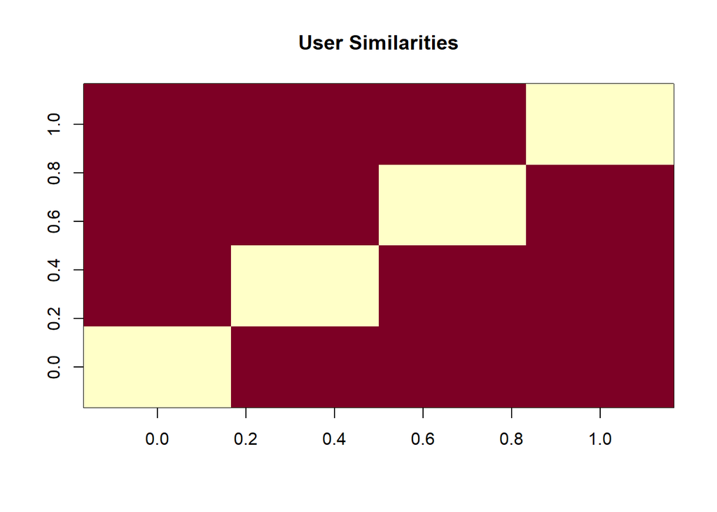

In the given matrix, each row and each column corresponds to a user, and each cell corresponds to the similarity between two users. The more red the cell is, the more similar two users are. Note that the diagonal is yellow, since it’s comparing each user with itself.

## Exploring Similarity Data - Films

```
##           1         2         3         4
## 1 0.0000000 0.9669732 0.9559341 0.9101276
## 2 0.9669732 0.0000000 0.9658757 0.9412416
## 3 0.9559341 0.9658757 0.0000000 0.9864877
## 4 0.9101276 0.9412416 0.9864877 0.0000000
```

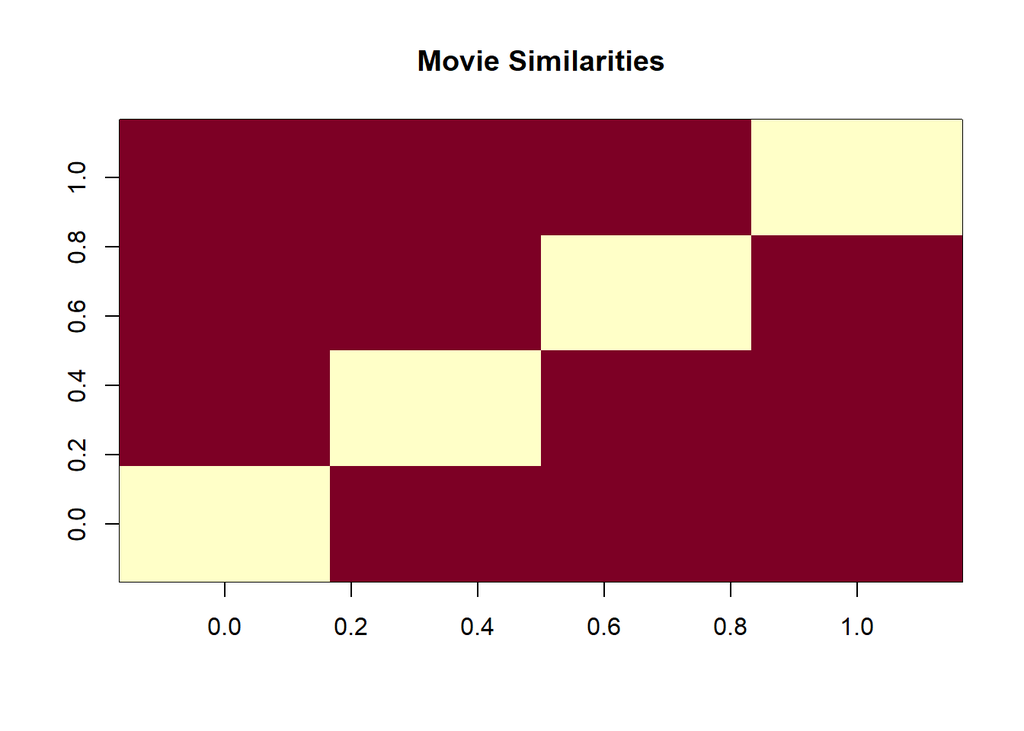

Likewise, each row and column corresponds to a movie, and each cell corresponds to the similarity between two movies The more red the cell is, the more similar two movies are. Note that the diagonal is yellow, since it’s comparing each user with itself.

## Further data exploration -Exploring the various values of ratings.

```r
ratingValues <-  as.vector(movie_ratingMatrix@data)
unique(ratingValues)  # what are unique values of ratings
```

```
##  [1] 0.0 5.0 4.0 3.0 4.5 1.5 2.0 3.5 1.0 2.5 0.5
```

```r
movie_rating_table <- table(ratingValues) # what is the count of each rating value
movie_rating_table
```

```
## ratingValues
##       0     0.5       1     1.5       2     2.5       3     3.5       4     4.5
## 6791761    1198    3258    1567    7943    5484   21729   12237   28880    8187
##       5
##   14856
```

### Distribution of the ratings

According to the documentation, a rating equal to 0 represents a missing value, so 0 was removed from the dataset before visualizing the results.

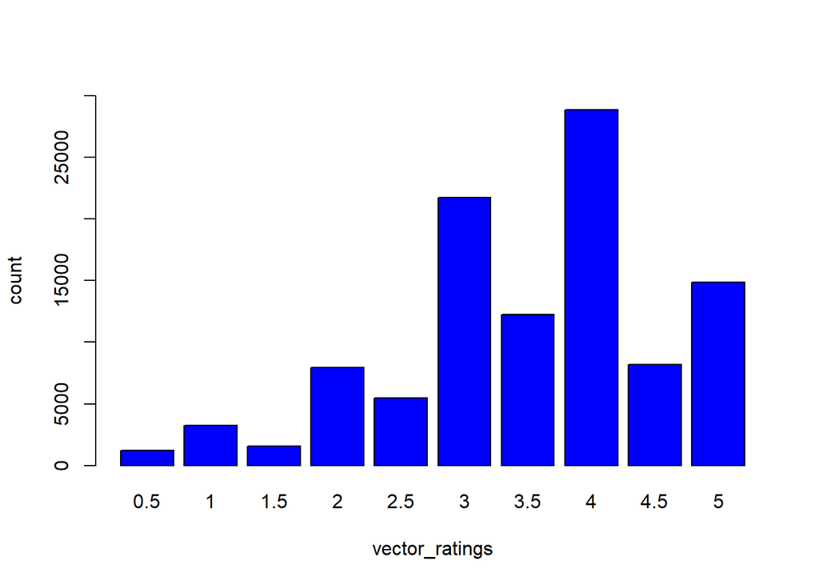

The majority of movies are rated with a score of 3 or higher. The most common rating is 4 as shown in the vector of ratings histogram plot.

### Number of views of the top movies

|  | movie | views_count | title |
| --- | --- | --- | --- |
| 296 | 296 | 325 | Pulp Fiction (1994) |
| 356 | 356 | 311 | Forrest Gump (1994) |
| 318 | 318 | 308 | Shawshank Redemption, The (1994) |
| 480 | 480 | 294 | Jurassic Park (1993) |
| 593 | 593 | 290 | Silence of the Lambs, The (1991) |
| 260 | 260 | 273 | Star Wars: Episode IV - A New Hope (1977) |

## Plot of the total count of the top 6 viewed films.

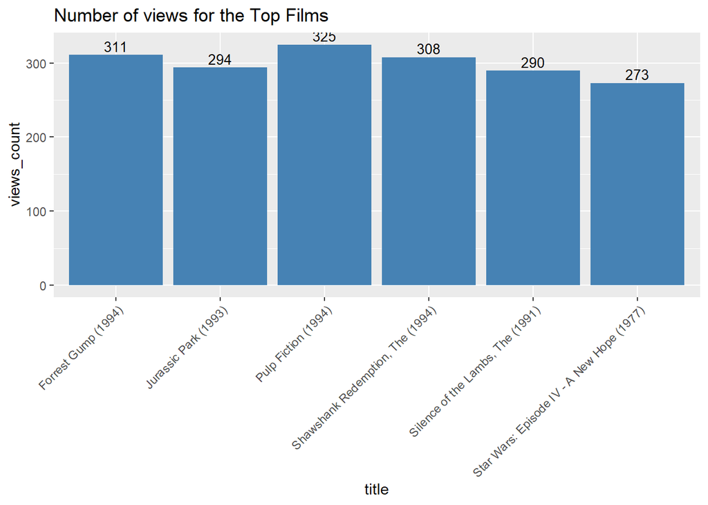

```r
ggplot(tabular_view_movies[1:6, ], aes(x = title, y = views_count)) +
  geom_bar(stat="identity", fill = 'steelblue') +
  geom_text(aes(label=views_count), vjust=-0.3, size=3.5) +
  theme(axis.text.x = element_text(angle = 45, hjust = 1)) +
  ggtitle("Number of views for the Top Films")
```

“Pulp Fiction (1994)” is the most viewed movie, exceeding the second-most-viewed “Forrest Gump (1994)” by 14 views.

### Distribution of the average movie rating

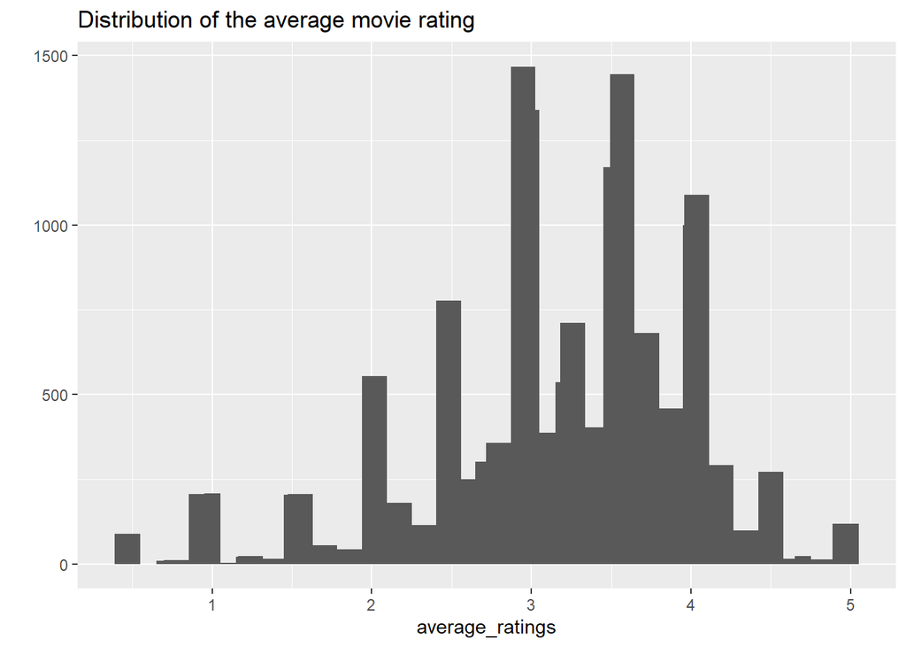

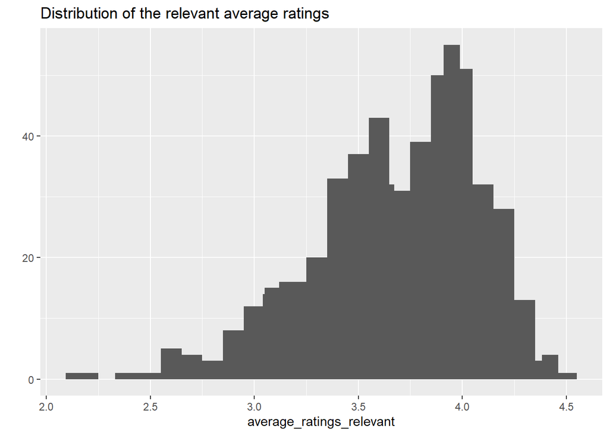

The first image above shows the Distribution of the average movie rating. The highest value is around 3, and there are a few movies whose rating is either 1 or 5. Probably, the reason is that these movies received a rating from a few people only, so we shouldn’t take them into account.

Once movies whose number of views is below a defined threshold of 50 was removed,a subset of only relevant movies was created. The second image above shows the distribution of the relevant average ratings. All the rankings are between 2.16 and 4.45. As expected, the extremes were removed. The highest value changes, and now it is around 4.

### Heatmap of Movie Ratings

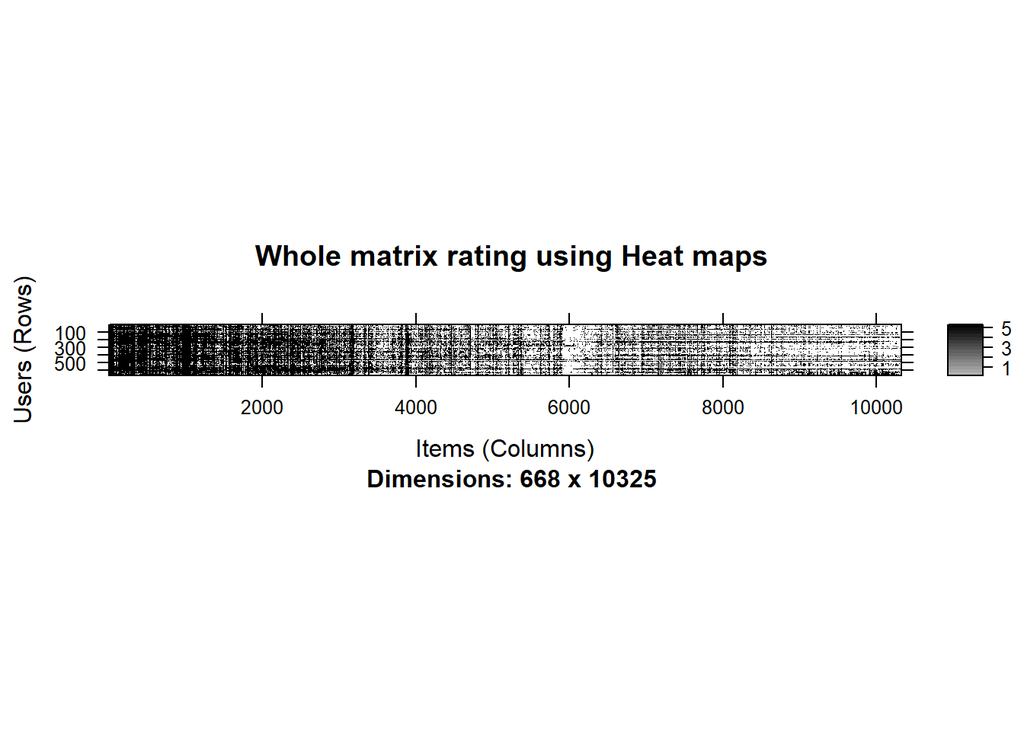

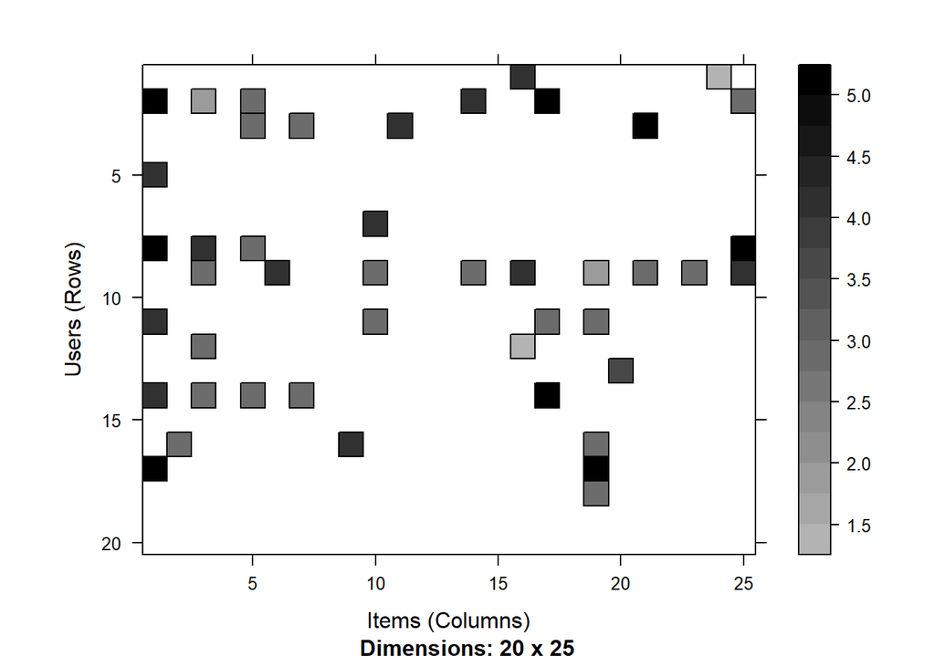

Since there are too many users and items, the first chart is hard to read. The second chart is built zooming in on the first rows and columns.

Some users saw more movies than the others. So, instead of displaying some random users and items, the most relevant users and items are selected. Thus only the users who have seen many movies and the movies that have been seen by many users are visualized. To identify and select the most relevant users and movies, I follow these steps:

1. Determine the minimum number of movies per user.
2. Determine the minimum number of users per movie.
3. Select the users and movies matching these criteria.

```
## [1] "Minimum number of movies per user:"
```

```
##     99%
## 1198.17
```

```
## [1] "Minimum number of users per movie:"
```

```
## 99%
## 115
```

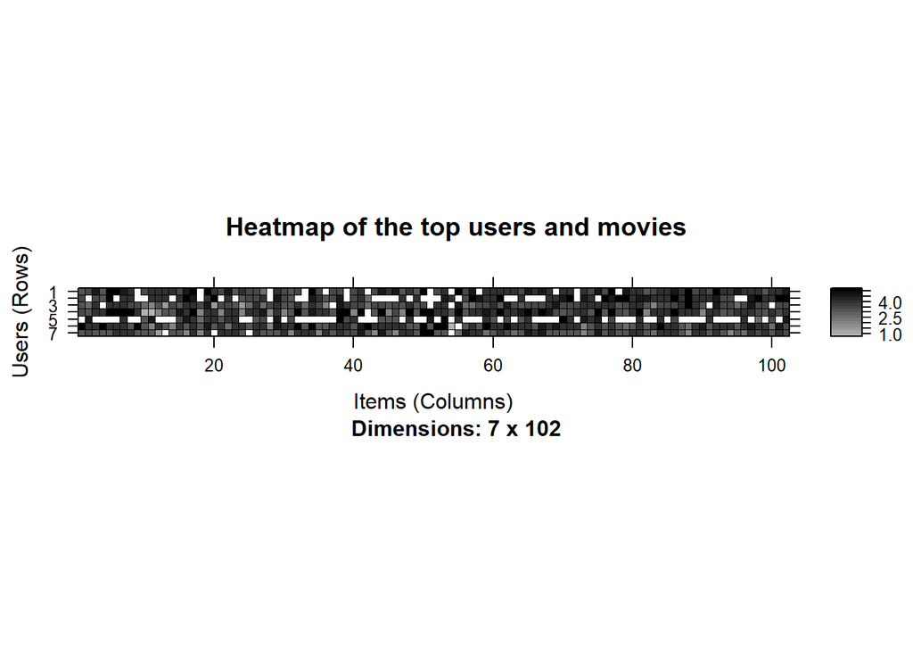

## Data Preparation

### Selecting Useful Data

For finding useful data in our dataset, we have set the threshold for the minimum number of users who have rated a film as 50. This is also same for minimum number of views that are per film. This way, we have filtered a list of watched films from least-watched ones.

```
## 420 x 447 rating matrix of class 'realRatingMatrix' with 38341 ratings.
```

From the above output of ‘movie_ratings’, we observe that there are 420 users and 447 films as opposed to the previous 668 users and 10325 films. We can now delineate our matrix of relevant users as follows

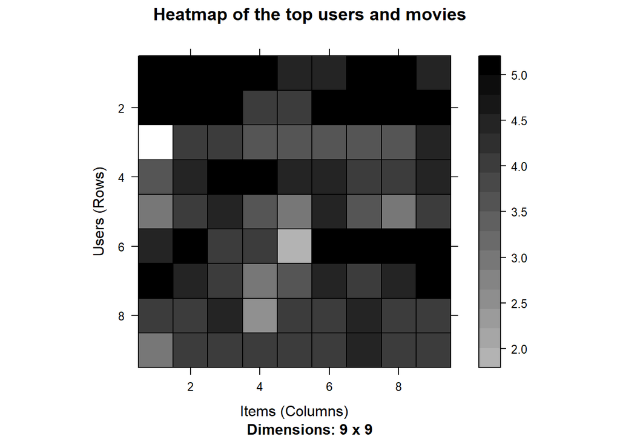

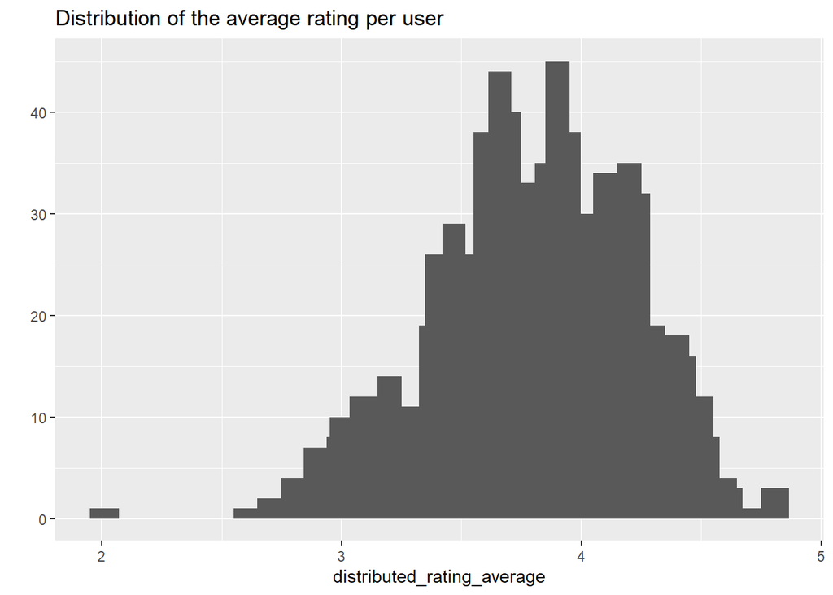

In the heatmap, some rows are darker than the others. This might mean that some users give higher ratings to all the movies. The distribution of the average rating per user across all the users varies a lot, as the Distribution of the average rating per user chart below shows.

### Data Normalization.

In the case of some users, there can be high ratings or low ratings provided to all of the watched films. This will act as a bias while implementing our model. normalizing our data removes this

```r
normalized_movie_ratings<- normalize(movie_ratingTreshold)
sum(rowMeans(normalized_movie_ratings) > 0.00001)
```

```
## [1] 0
```

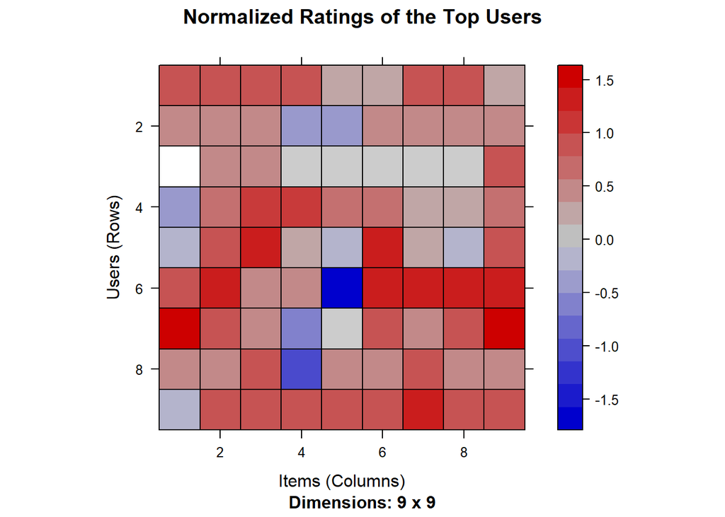

```r
image(normalized_movie_ratings[rowCounts(normalized_movie_ratings) > minrated_movies, colCounts(normalized_movie_ratings) > minimum_user_who_rated],main = "Normalized Ratings of the Top Users")
```

There are still some lines that seem to be more blue or more red in the Normalized Ratings of the Top Users heatmap. The reason is that I am visualizing only the top movies. I have already checked that the average rating is 0 for each user.

### Data Binarization and Heatmap of the top users and movies.

Some recommendation models work on binary data, so it might be useful to binarize the data, that is, define a table containing only 0s and 1s. The 0s will be either treated as missing values or as bad ratings.

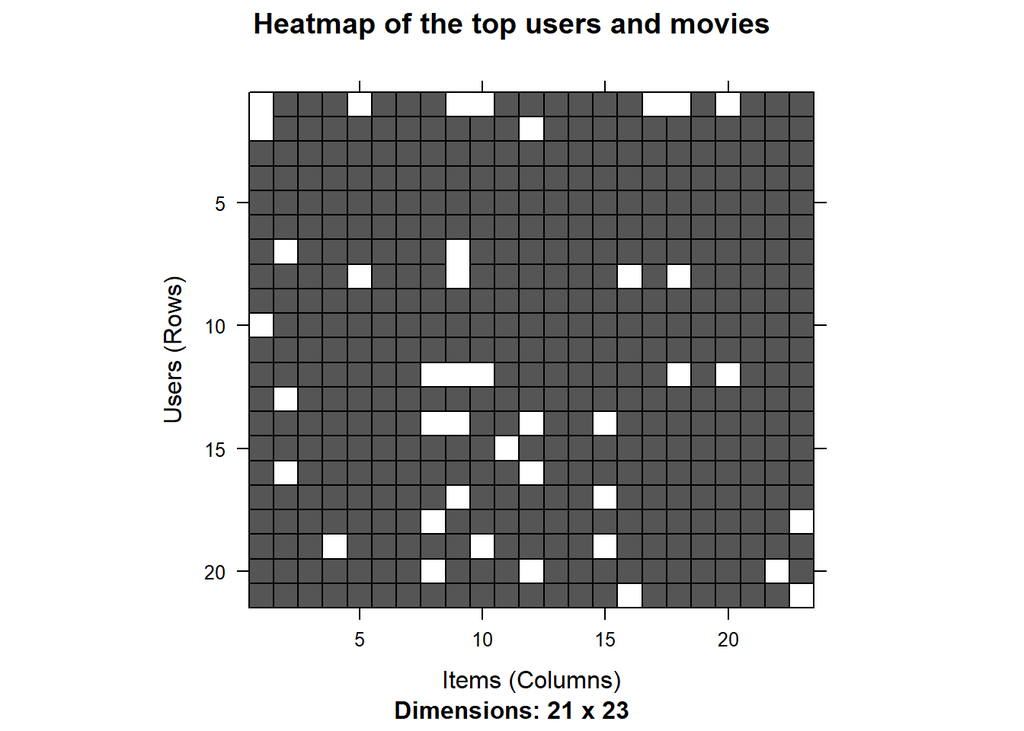

```r
#visualizing 5 percent portion of each of binarized matrices.
binary_min_movies <- quantile(rowCounts(movie_ratingTreshold),0.95)
binary_min_users <- quantile(colCounts(movie_ratingTreshold),0.95)

good_rated_films <- binarize(movie_ratingTreshold,minRating = 3)

image(good_rated_films[rowCounts(movie_ratingTreshold) > binary_min_movies ,colCounts(movie_ratingTreshold) > binary_min_users], main = "Heatmap of the top users and movies")
```

## Defining training and test sets.

## Item-based Collaborative Filtering Model

## Displaying recommender parameters

Let’s have a look at the default parameters of IBCF model. Here, *k* is the number of items to compute the similarities among them in the first step. After, for each item, the algorithm identifies its *k* most similar items and stores the number. *method* is a similarity funtion, which is *Cosine* by default, may also be *pearson*. I create the model using the default parameters of method = Cosine and k=30.

```r
recommendation_info_ibcf <- recommenderRegistry$get_entries(dataType ="realRatingMatrix")
recommendation_info_ibcf$IBCF_realRatingMatrix$parameters
```

```
## $k
## [1] 30
##
## $method
## [1] "Cosine"
##
## $normalize
## [1] "center"
##
## $normalize_sim_matrix
## [1] FALSE
##
## $alpha
## [1] 0.5
##
## $na_as_zero
## [1] FALSE
```

## Building the IBCF Recommender Model with training data

```r
recommen_model_IBCF <-  Recommender(data = training_set, method = "IBCF", parameter = list(k = 30))
recommen_model_IBCF
```

```
## Recommender of type 'IBCF' for 'realRatingMatrix'
## learned using 334 users.
```

```r
model_details_IBCF <- getModel(recommen_model_IBCF)
model_details_IBCF$data
```

[output not shown]

## Exploring the recommender model:

```
## [1] "IBCF: Reduced similarity matrix"
```

```
## [1] 30
```

```
## [1] "dgCMatrix"
## attr(,"package")
## [1] "Matrix"
```

```
## [1] 447 447
```

## Applying recommender system on the dataset:

```r
predicted_recommendations_IBCF <- predict(object = recommen_model_IBCF,newdata = testing_set, n = 10)# predict() function that will identify similar items and will rank them appropriately.
# Top_recommendations variable initialized to 10, specifying the number of films to each user.

predicted_recommendations_IBCF
```

```
## Recommendations as 'topNList' with n = 10 for 86 users.
```

## Applying the IBCF recommender model on the test set

```r
user1 <- predicted_recommendations_IBCF@items[[1]] # recommendation for the first user
movies_user1 <- predicted_recommendations_IBCF@itemLabels[user1]
movies_user2 <- movies_user1
for (index in 1:10){
  movies_user2[index] <- as.character(subset(IMDB_movies,
                                         IMDB_movies$movieId == movies_user1[index])$title)
}
movies_user2
```

```
##  [1] "Mask, The (1994)"
##  [2] "Mrs. Doubtfire (1993)"
##  [3] "North by Northwest (1959)"
##  [4] "Maltese Falcon, The (1941)"
##  [5] "English Patient, The (1996)"
##  [6] "Star Trek: First Contact (1996)"
##  [7] "Air Force One (1997)"
##  [8] "Lethal Weapon 2 (1989)"
##  [9] "Donnie Darko (2001)"
## [10] "City Slickers II: The Legend of Curly's Gold (1994)"
```

```
## [1] 10 86
```

```
##       [,1] [,2] [,3] [,4]
##  [1,]  367  104  253  551
##  [2,]  500  158 1876 1479
##  [3,]  908 2710  350 2424
##  [4,]  913   25 1101 1374
##  [5,] 1183  435 1203 1356
##  [6,] 1356  141 1408  586
##  [7,] 1608  236 2791 3703
##  [8,] 2001 1258 3175 2167
##  [9,] 4878 2490  802  442
## [10,]  432  780 5060  292
```

The above matrix contain *movieId* of each recommended movie (rows) for the first four users (columns) in our test dataset. I also compute how many times each movie got recommended and build the related frequency histogram:

It’s also possible to define a matrix with the recommendations for each user. I visualize the recommendations for the first four users:

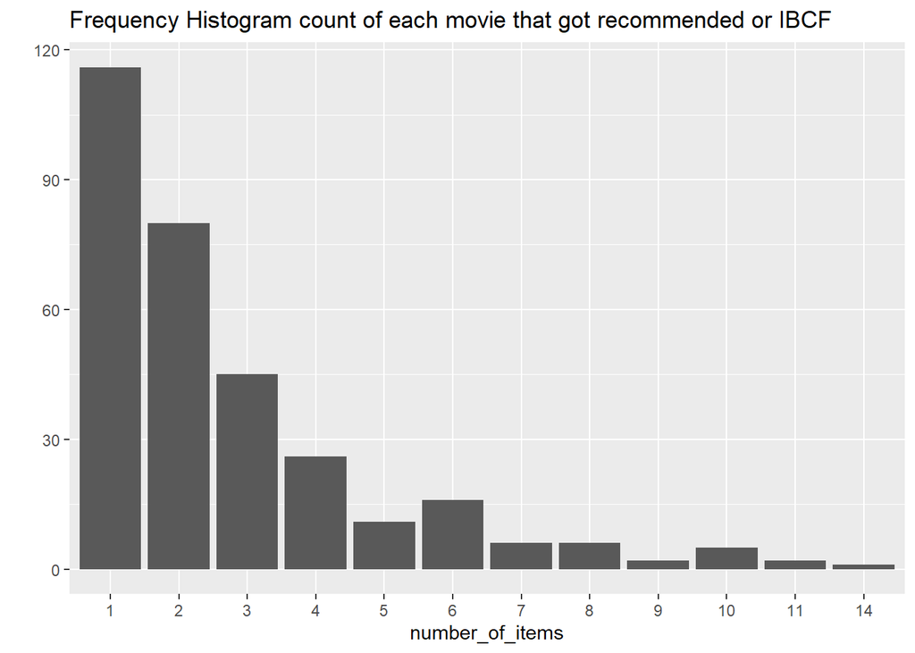

|  | Movie title | No of items |
| --- | --- | --- |
| 3 | Grumpier Old Men (1995) | 14 |
| 5 | Father of the Bride Part II (1995) | 11 |
| 21 | Get Shorty (1995) | 11 |
| 6 | Heat (1995) | 10 |

IBCF recommends items on the basis of the similarity matrix. It’s an eager-learning model, that is, once it’s built, it doesn’t need to access the initial data. For each item, the model stores the k-most similar, so the amount of information is small once the model is built. This is an advantage in the presence of lots of data.

Most of the movies have been recommended only a few times, and a few movies have been recommended more than 10 times.

## Building the recommendation system with training data:

```
## Recommender of type 'UBCF' for 'realRatingMatrix'
## learned using 334 users.
```

```
## 334 x 447 rating matrix of class 'realRatingMatrix' with 31675 ratings.
## Normalized using center on rows.
```

## Applying the UBCF recommender model on the test set

```r
n_recommended_ubcf <- 10
recc_predicted_ubcf <- predict(object = recommen_model_UBCF,newdata = testing_set, n = n_recommended_ubcf)
recc_predicted_ubcf
```

```
## Recommendations as 'topNList' with n = 10 for 86 users.
```

## Using UBCF Recommender on User 1

```r
ubcf_user1 <- recc_predicted_ubcf@items[[1]] # recommendation for the first user
movies_ubcf_user1 <- recc_predicted_ubcf@itemLabels [ubcf_user1]
movies_ubcf_user2 <-  movies_ubcf_user1

for (index in 1:10) { movies_ubcf_user2[index] <- as.character(subset(IMDB_movies, IMDB_movies$movieId == movies_ubcf_user1[index])$title)
}
movies_ubcf_user2
```

```
##  [1] "Total Recall (1990)"
##  [2] "Jungle Book, The (1967)"
##  [3] "Cool Hand Luke (1967)"
##  [4] "Mummy, The (1999)"
##  [5] "Client, The (1994)"
##  [6] "Babe (1995)"
##  [7] "Snow White and the Seven Dwarfs (1937)"
##  [8] "Piano, The (1993)"
##  [9] "Much Ado About Nothing (1993)"
## [10] "Sound of Music, The (1965)"
```

## Explore results

Let’s take a look at the first four users:

```r
recommendation_matrix_ubcf <- sapply( recc_predicted_ubcf@items, function(x){as.integer(colnames(movie_ratingTreshold)[x])})

dim(recommendation_matrix_ubcf)
```

```
## [1] 10 86
```

```r
recommendation_matrix_ubcf[, 1:4]
```

```
##       [,1]  [,2] [,3] [,4]
##  [1,] 2916   923 3408 1584
##  [2,] 2078  1201 2716 2268
##  [3,] 1276  3421 1479 1517
##  [4,] 2617 56367 1584 1285
##  [5,]  350  2268 1610 2987
##  [6,]   34  2640 2194    6
##  [7,]  594    62 2700 1407
##  [8,]  509  1047 3175 1704
##  [9,]  497  1252 1729 1213
## [10,] 1035  1225   10   19
```

The above matrix contain *movieId* of each recommended movie (rows) for the first four users (columns) in our test dataset.

I also compute how many times each movie got recommended and build the related frequency histogram:

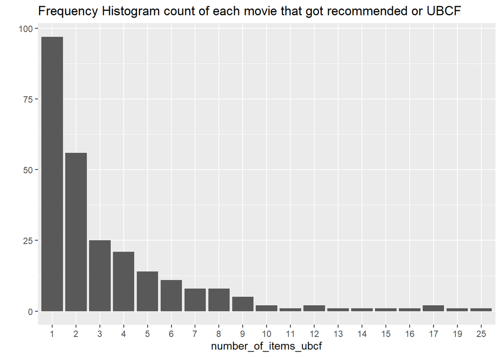

Let’s take a look at the top titles:

|  | Movie title | No of items |
| --- | --- | --- |
| 2268 | Few Good Men, A (1992) | 25 |
| 1584 | Contact (1997) | 19 |
| 5669 | Bowling for Columbine (2002) | 17 |
| 49530 | Blood Diamond (2006) | 17 |

Comparing the results of UBCF with IBCF helps find some useful insight on different algorithms. UBCF needs to access the initial data. Since it needs to keep the entire database in memory, it doesn’t work well in the presence of a big rating matrix. Also, building the similarity matrix for IBCF requires a lot of computing power and time.

## Evaluating the Recommender Systems

We need two trainig and testing data to evaluate the model. There are several methods to create them: 1) splitting the data into training and test sets, 2) bootstrapping, 3) using k-fold.

## Training and Test set split Recommender system.

```r
percentage_training <- 0.8

#For each user in the test set, we need to define how many items to use to generate recommendations. For this, I first check the minimum number of items rated by users to be sure there will be no users with no items to test.
min(rowCounts(movie_ratingTreshold))
```

```
## [1] 8
```

```r
items_to_keep <- 5 #number of items to generate recommendations
rating_threshold <- 3 # threshold with the minimum rating that is considered good
n_eval <- 1

eval_sets <- evaluationScheme(data = movie_ratingTreshold, method = "split",train = percentage_training, given = items_to_keep, goodRating = rating_threshold, k = n_eval)
eval_sets
```

```
## Evaluation scheme with 5 items given
## Method: 'split' with 1 run(s).
## Training set proportion: 0.800
## Good ratings: >=3.000000
## Data set: 420 x 447 rating matrix of class 'realRatingMatrix' with 38341 ratings.
```

```r
getData(eval_sets, "train") # training set
```

```
## 336 x 447 rating matrix of class 'realRatingMatrix' with 30665 ratings.
```

```r
getData(eval_sets, "known") # set with the items used to build the recommendations
```

```
## 84 x 447 rating matrix of class 'realRatingMatrix' with 420 ratings.
```

```r
getData(eval_sets, "unknown") # set with the items used to test the recommendations
```

```
## 84 x 447 rating matrix of class 'realRatingMatrix' with 7256 ratings.
```

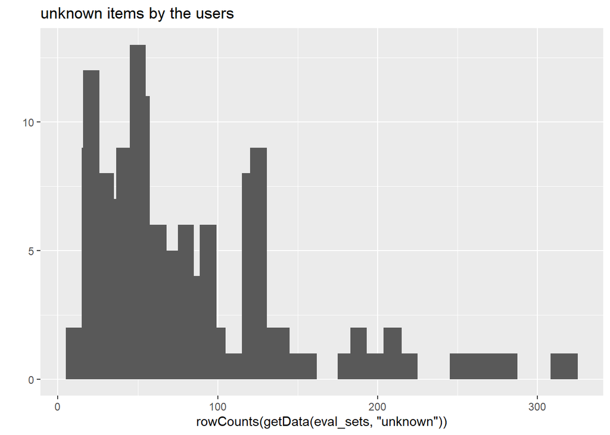

```r
qplot(rowCounts(getData(eval_sets, "unknown"))) + geom_histogram(binwidth = 10) +  ggtitle("unknown items by the users")
```

```r
#The "unknown items by users" plot displays the unknown items by the users, which varies a lot.
```

## Bootstrapping the data

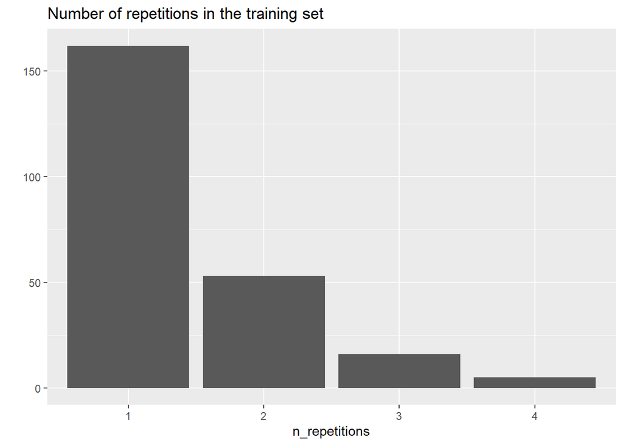

```r
eval_sets <- evaluationScheme(data = movie_ratingTreshold, method = "bootstrap", train = percentage_training, given = items_to_keep, goodRating = rating_threshold, k = n_eval)

table_train <- table(eval_sets@runsTrain[[1]])
n_repetitions <- factor(as.vector(table_train))

qplot(n_repetitions) + ggtitle("Number of repetitions in the training set")
```

```r
# The boottrap chart shows that most of the users have been sampled fewer than four times.
```

## Using cross-validation to validate models

The k-fold cross-validation approach is the most accurate one, although it’s computationally heavier.

Using this approach, we split the data into some chunks, take a chunk out as the test set, and evaluate the accuracy. Then, we can do the same with each other chunk and compute the average accuracy.

```r
n_fold <- 4
eval_sets <- evaluationScheme(data = movie_ratingTreshold,
                              method = "cross-validation",
                              k = n_fold,
                              given = items_to_keep,
                              goodRating = rating_threshold)
size_sets <- sapply(eval_sets@runsTrain, length)
size_sets #Using 4-fold approach, we get four sets of the same size 315.
```

```
## [1] 315 315 315 315
```

## Evaluating the ratings

For this project, I proceeded with using the k-fold cross validation approach to Evaluate the ratings.

Now, I compute the accuracy measures for each user. Most of the RMSEs (Root mean square errors) are in the range of 0.5 to 1.8:

```
##           RMSE       MSE       MAE
## [1,] 0.9465800 0.8960137 0.7644256
## [2,] 0.9296738 0.8642934 0.7197873
## [3,] 0.8883800 0.7892190 0.7175787
## [4,] 0.6780654 0.4597727 0.4785885
## [5,] 0.8856800 0.7844291 0.7016499
## [6,] 1.1009836 1.2121650 0.8901916
```

In order to have a performance index for the whole model, I specify *byUser* as FALSE and compute the average indices:

```
##      RMSE       MSE       MAE
## 1.0213755 1.0432079 0.7944876
```

## Evaluating the recommendations

Another way to measure accuracies is by comparing the recommendations with the purchases having a positive rating. For this, I can make use of a prebuilt *evaluate* function in *recommenderlab* library. The function evaluate the recommender performance depending on the number *n* of items to recommend to each user. I use *n* as a sequence n = seq(10, 100, 10).

The first rows of the resulting performance matrix is presented below:

```r
# Evaluating the recommendations
results <- evaluate(x = eval_sets,
                    method = model_to_evaluate,
                    n = seq(10, 100, 10))
```

```
## UBCF run fold/sample [model time/prediction time]
##   1  [0.01sec/0.64sec]
##   2  [0.02sec/0.42sec]
##   3  [0sec/0.6sec]
##   4  [0sec/0.84sec]
```

```r
(getConfusionMatrix(results)[[1]])
```

```
##            TP       FP       FN       TN precision     recall        TPR
## 10   1.428571  8.47619 76.89524 355.2000 0.1442308 0.01898343 0.01898343
## 20   3.257143 16.55238 75.06667 347.1238 0.1644231 0.04263348 0.04263348
## 30   5.304762 24.40952 73.01905 339.2667 0.1785256 0.07267518 0.07267518
## 40   7.495238 32.12381 70.82857 331.5524 0.1891827 0.09972987 0.09972987
## 50   9.666667 39.85714 68.65714 323.8190 0.1951923 0.12820925 0.12820925
## 60  11.990476 47.43810 66.33333 316.2381 0.2017628 0.16114805 0.16114805
## 70  14.352381 54.98095 63.97143 308.6952 0.2070055 0.19519353 0.19519353
## 80  16.580952 62.65714 61.74286 301.0190 0.2092548 0.22568767 0.22568767
## 90  18.723810 70.41905 59.60000 293.2571 0.2100427 0.25153105 0.25153105
## 100 20.914286 78.13333 57.40952 285.5429 0.2111538 0.28052470 0.28052470
##            FPR
## 10  0.02386035
## 20  0.04617430
## 30  0.06770173
## 40  0.08850618
## 50  0.10963100
## 60  0.13015031
## 70  0.15068527
## 80  0.17162032
## 90  0.19247964
## 100 0.21359093
```

In order to have a look at all the splits at the same time, I sum up the indices of columns TP, FP, FN and TN:

```
##           TP        FP       FN       TN
## 10  5.647619  34.06667 296.6762 1431.610
## 20 12.323810  67.10476 290.0000 1398.571
## 30 20.057143  99.08571 282.2667 1366.590
## 40 27.904762 130.95238 274.4190 1334.724
## 50 36.047619 162.52381 266.2762 1303.152
## 60 44.533333 193.75238 257.7905 1271.924
```

Finally, I plot the ROC and the precision/recall curves:

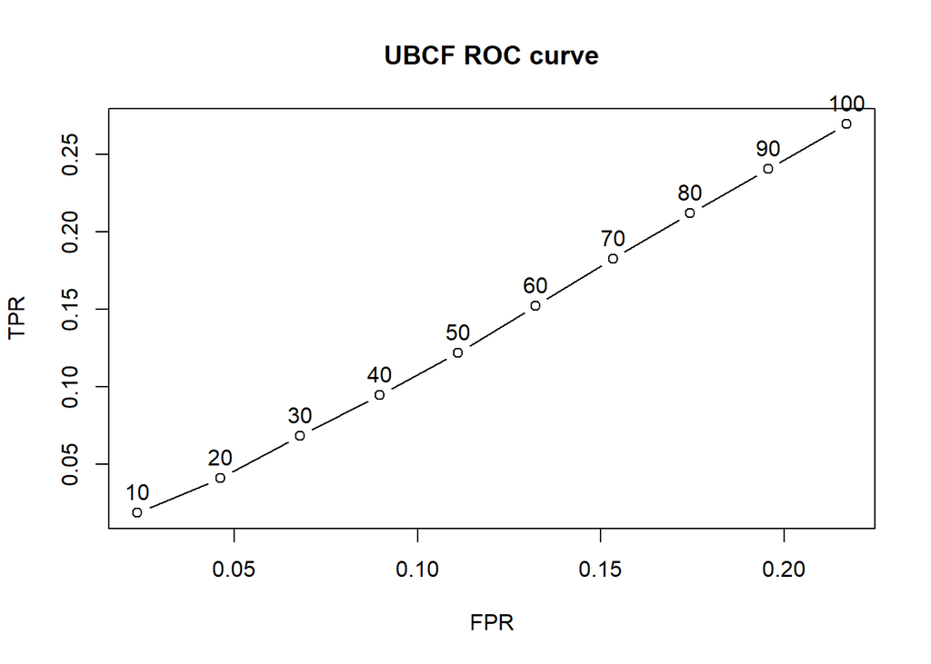

```r
plot(results, annotate = TRUE, main = "UBCF ROC curve")
```

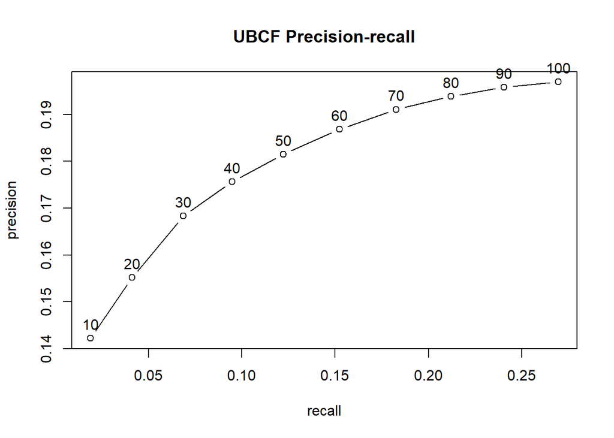

```r
plot(results, "prec/rec", annotate = TRUE, main = "UBCF Precision-recall")
```

```r
# If a small percentage of rated movies is recommended, the precision decreases. On the other hand, the higher percentage of rated movies is recommended the higher is the recall.
```

## Comparing models

Then, I define a different set of numbers for recommended movies (n_recommendations <- c(1, 5, seq(10, 100, 10))), run and evaluate the models:

```
## IBCF run fold/sample [model time/prediction time]
##   1  [0.87sec/0.06sec]
##   2  [0.88sec/0.06sec]
##   3  [0.82sec/0.07sec]
##   4  [0.81sec/0.06sec]
## IBCF run fold/sample [model time/prediction time]
##   1  [0.55sec/0.06sec]
##   2  [0.53sec/0.05sec]
##   3  [0.53sec/0.11sec]
##   4  [0.55sec/0.09sec]
## UBCF run fold/sample [model time/prediction time]
##   1  [0.01sec/0.5sec]
##   2  [0sec/0.56sec]
##   3  [0sec/0.49sec]
##   4  [0sec/0.47sec]
## RANDOM run fold/sample [model time/prediction time]
##   1  [0sec/0.06sec]
##   2  [0sec/0.05sec]
##   3  [0.02sec/0.08sec]
##   4  [0.01sec/0.11sec]
```

```
## IBCF_cos IBCF_cor UBCF_cos   random
##     TRUE     TRUE     TRUE     TRUE
```

The following table presents as an example the first rows of the performance evaluation matrix for the IBCF with Cosine distance:

```
##    precision      recall         TPR         FPR
## 1  0.2005090 0.002612613 0.002612613 0.002156626
## 5  0.1859351 0.012345443 0.012345443 0.010997108
## 10 0.1756257 0.023745563 0.023745563 0.022343148
## 20 0.1641023 0.043032963 0.043032963 0.045058824
## 30 0.1649469 0.063428544 0.063428544 0.066863112
## 40 0.1636878 0.080750409 0.080750409 0.088203023
```

## Identifying the most suitable model

I compare the models by building a chart displaying their ROC curves and Precision/recall curves.

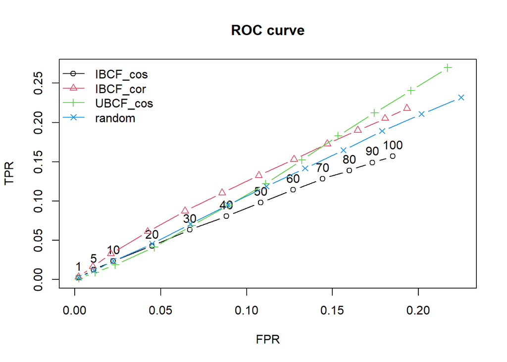

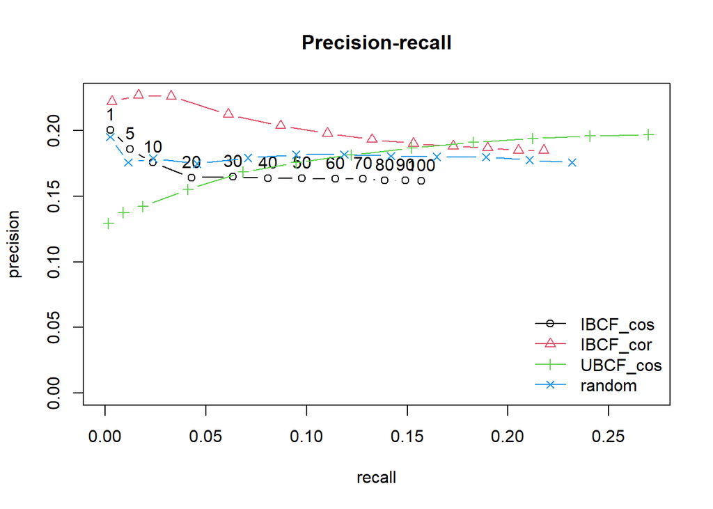